# Bayesiaanse Beleidsanalyse

Iets grappigs te verzinnen

Jan Boone & Misja Mikkers

Tilburg University and University of Twente

2 juli 2025

## Inleiding

## Quiz: Hoe interpreteer jij waarschijnlijkheid?

We starten met een korte quiz (gebaseerd op Johnson, Ott, en Dogucu (2022)) met vier vragen om te ontdekken hoe jij naar waarschijnlijkheid kijkt.

**Instructies voor deelnemers**

- Lees iedere vraag zorgvuldig.
- Bespreek je antwoorden kort met je buurvrouw of man.
- Noteer je antwoorden (A, B of C) op papier.
- We bespreken de antwoorden en de achterliggende gedachten plenair na de quiz.

## Vraag 1

Bij het opgooien van een eerlijke munt zeggen we dat de kans op ‘kop’ 0,5 is. Hoe interpreteer jij deze kans?

1. Als ik de munt heel vaak opgooi, komt ongeveer 50% kop.
2. Kop en munt zijn nu even plausibel.
3. Beide interpretaties (A en B) zijn logisch.

## Vraag 2

Elf dagen voor de verkiezingen gaf FiveThirtyEight Trump een kans van 51% om te winnen. Hoe interpreteer jij deze kans?

1. Als we de verkiezingen 100 keer zouden houden, wint Trump 51 keer.
2. Trump heeft iets meer kans om te winnen dan om te verliezen.
3. Dit slaat nergens op: Trump wint of verliest, de kans is 0 of 1.

## Vraag 3

We laten 2 statements zien:

1. Tessa zegt dat ze elk liedje van Taylor Swift binnen een paar tonen kan herkennen. Ze wordt getest: 7 liedjes, 7 keer goed.
2. Paul de Octopus voorspelde in 2010 de uitslag van alle 7 WK-wedstrijden van Duitsland correct.

Wat denk jij?

1. Ik vertrouw meer op Tessa’s claim dan op die van Paul.
2. Het bewijs voor Tessa en Paul is even sterk.

## Vraag 4

Een arts zegt dat je positief hebt getest op een zeldzame ziekte. Wat is de belangrijkste vraag om te stellen?

1. Wat is de kans dat ik écht ziek ben?
2. Wat is de kans dat ik een positieve test krijg als ik níet ziek ben?

## Tellen van je score

Tel je punten op:

| Vraag | A (punten) | B (punten) | C (punten) |
| --- | --- | --- | --- |
| 1 | 1 | 3 | 2 |
| 2 | 1 | 3 | 1 |
| 3 | 3 | 1 |  |
| 4 | 3 | 1 |  |

**Interpretatie van je score**

- 4–5 punten: Je denkt nu vooral Frequentistisch.
- 6–8 punten: Je ziet sterke kanten in beide benaderingen.
- 9–12 punten: Je neigt sterk naar het Bayesiaanse denken.

## Frequentistisch versus Bayesiaans: de belangrijkste verschillen

| Aspect | Frequentistisch | Bayesiaans |
| --- | --- | --- |
| Kans (P) | Lange termijn frequentie | Geloofsgraad / plausibiliteit |
| Focus | Variabiliteit van data | Onzekerheid over uitkomsten |
| Informatiebron | Data | Data + voorkennis (‘priors’) |
| Wat je berekent | $P(\text{data \| hypothese})$ | $P(\text{hypothese \| data})$ |

# Bayesian Learning

## Bayesian Learning

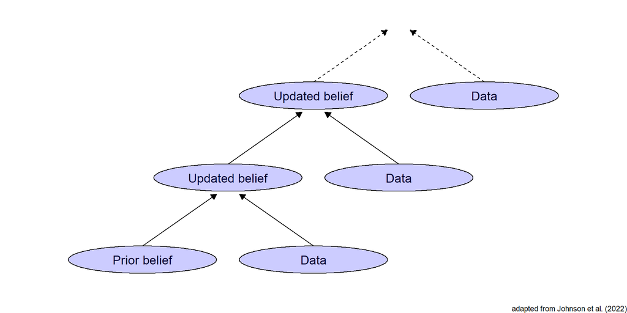

## Bayesian Learning

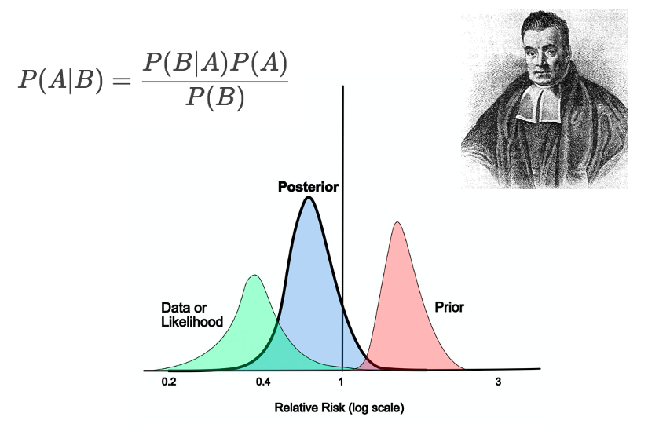

## Eerste Bayesiaanse analyse: het DGP

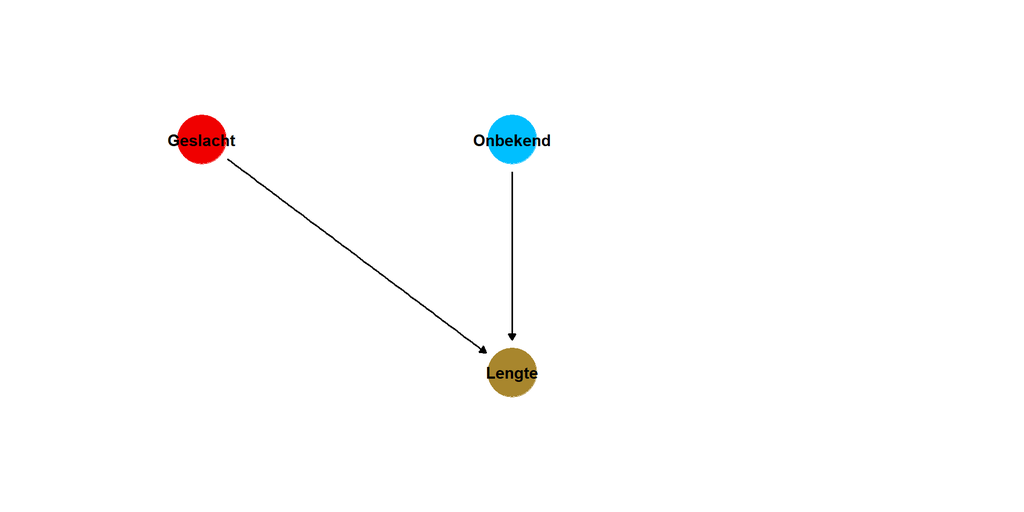

## Eerste Bayesiaanse analyse

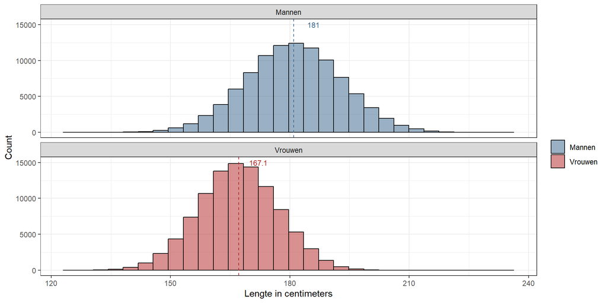

## Schatting model met veel data en strakke prior

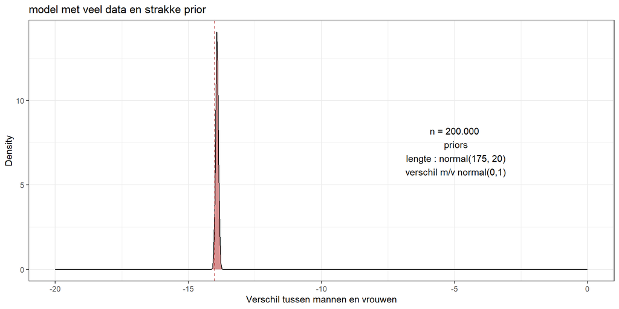

## Nu zelfde schatting met heel beperkte data!

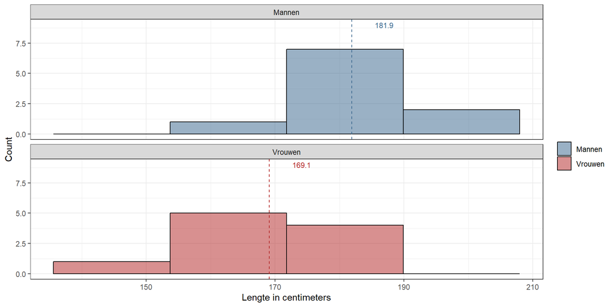

## Resultaat

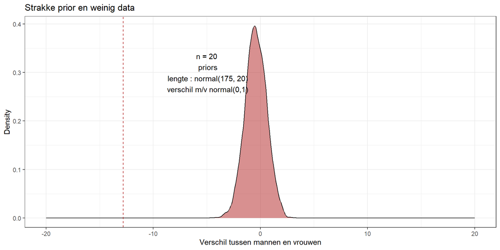

## Schatting model met kleine sample size en betere prior

[figure not shown]

# Een beleidsvoorbeeld

## In de praktijk: onzekerheid over beleidsanalyse

- de onzekerheid over de schatting van coefficienten vertaalt zich in onzekerheid van beleidsrelevante keuzes
- een voorbeeld:
  - de overheid wil een publiek goed van 18k (per capita) financieren met inkomensbelasting
  - er is belasting systeem met 3 schuiven en een oplopende marginale belasting tarief
  - wij schatten de (Pareto) verdeling van inkomens
  - de onzekerheid van de schatting van deze parameters bepaalt of het lukt om het publieke goed te financieren
  - dit is een niet lineare transformatie van de onzekerheid, frequentisme is hier niet goed in

## Simulatie

- we hebben sample gegenereerd van een Pareto inkomens verdeling
- met sample hebben we de parameters van deze verdeling geschat
- deze geschatte parameters $\alpha, m$ hebben een verdeling gegeven de data
- posterior verdeling: $p(\alpha,m|data)$
- het algoritme sampled van deze verdeling: er zijn 4000 $\alpha$ and $m$ (4 keer 1000 samples)

## Onzekerheid

- voor een geven $\alpha, m$, is er een belasting opbrengst (met de niet lineare belasting functie)
- voor 4000 $\alpha, m$ is er een verdeling van deze belasting opbrengt

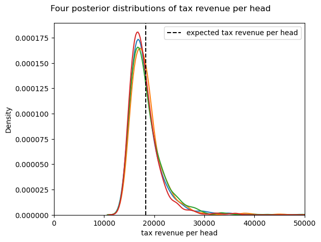

verdeling belasting opbrengst

## Significantie

- stel de verwachte belasting opbrengst is 17k (per capita)
- is dit significant verschil met benchmark 18k?
- is helemaal niet relevant voor beleidsanalyse
- Bayesiaan: verwachte belasting opbrengst is 18,336k
- kans dat de threshold niet gehaald wordt is 58%

## Wat is een goede keuze voor het top marginal tarief

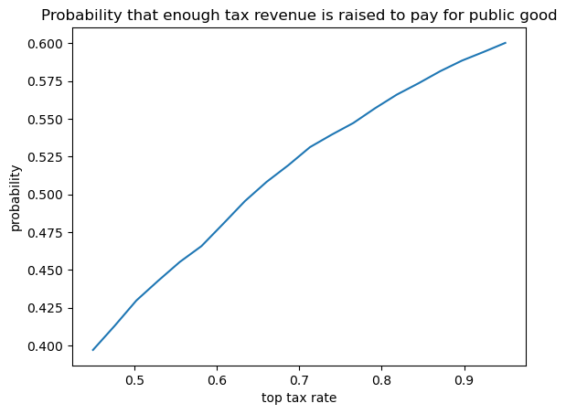

kans dat de benchmark gehaald wordt

## andere voorbeelden

- arbeidsaanbod elasticteit: totale belasting opbrengsten als functie van marginal tarief inkomsten belasting
- eigen risico elasticeit: total zorg uitgaven
- vraagelasticiteit NS: prijzen treinkaartjes, hoeveel autos op de weg
- onzekerheid over de schattingen die niet triviaal vertaald in onzekerheid over beleidsuitkomsten
- geintegreerde schattingsmethod en scenario analyse

## Literatuur

Johnson, Alicia A, Miles Q Ott, en Mine Dogucu. 2022. *Bayes rules!: An introduction to applied Bayesian modeling*. Chapman; Hall/CRC.